# MN High School Wrestling Weight Classes

Data and charts from the 2019-2020 season for every school (sourced from TrackWrestling.com)

## Distribution of Weight Classes

This chart shows the distribution across all weight classes for grades 9th - 12th. This bar chart is sorted by most to least:

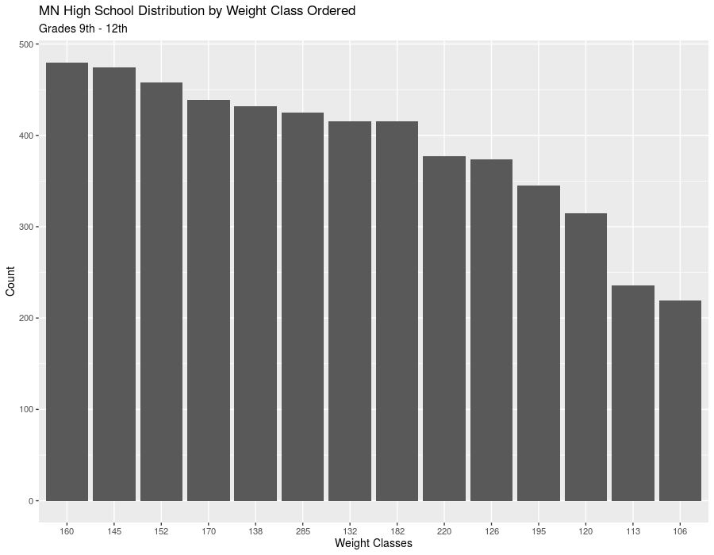

If you break out each grade, you can see the Freshman class skews heavily to the lighter side while Sophmores on up skew to the heavier side.

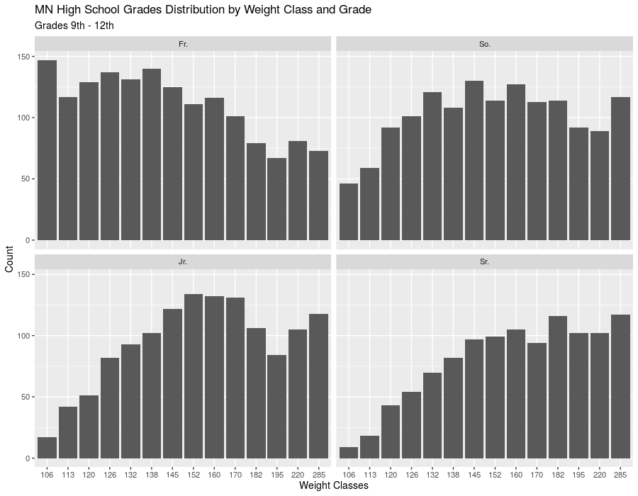

## State Tournament Participation by Grade and Weight Class

Looking at the state tournament participation, the participation in the middle and upper weights is dominated by upper classman.

The following table was sourced from TStuff.com from 2016-2020 for all three classes:

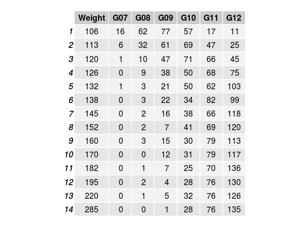